# Análise de Regressão sobre Avaliações do IMDb

Modelos Lineares I

Caio Salviano (caiosalviano@id.uff.br)

Universidade Federal Fluminense

29/06/2026

# 1 Introdução

## 1.1 Introdução

**O que é o IMDb?**

- Maior base de dados online sobre filmes e séries.
- Usuários registrados atribuem notas de **1 a 10** por título.
- A nota exibida é a **média ponderada** dos votos recebidos.

**Relevância:**

- A nota IMDb influencia decisões de distribuição e streaming
- Serve como métrica de qualidade percebida pelo público geral
- Amplamente usada em pesquisas de preferência do consumidor

**Na Literatura:**

- **Hsu et al. (2014)**:

> “some predictors profoundly affect user rating, such as writers, actors and directors.”
- **Miyashiro (2017)**: Modelo inicial probre. Aplicou MMQP na variável oscar.
- **Burns (2018)**: Modelo com 5 preditores teve um R² de 0,2993.
- **Chandra (2019)**: Modelos teve FIVs altos. R² final de 0,365.
- **Cini & Abela (2025)**:

> “Many factors that influence a movie’s success (such as audience reception or cultural timing) are unpredictable”
- **Rudro et al. (2025)**: XGBoost com R² de 0,3748

# 2 Material

## 2.1 Os dados

**Origem dos Dados**

- Fonte original: [Kaggle](https://www.kaggle.com/datasets/raedaddala/top-500-600-movies-of-each-year-from-1960-to-2024/data) - *Raed Addala*
- Tratamento Preliminar: [Base Dos Dados](https://basedosdados.org/dataset/6ba4745d-f131-4f8e-9e55-e8416199a6af?table=79de8c5e-9c21-4398-a9fb-bc40e6d6e77f) - *Patrick Teixeira*

**Composição dos Dados**

- Observações: 33.600 linhas;
- Variáveis: 23 colunas;
  - Numéricas: 11;
  - Categóricas: 12;
- Cobertura: 1960 – 2024.

**Estrutura dos Dados**

| Variável | Descrição | Tipo |
| --- | --- | --- |
| `id` | Identificador do filme | STRING |
| `title` | Título | STRING |
| `link` | Link IMDb | STRING |
| `year` | Ano de lançamento | INT64 |
| `duration` | Duração | STRING |
| `rating_mpa` | Classificação etária (MPA) | STRING |
| `rating_imdb` | Nota IMDb | FLOAT64 |
| `vote` | Número de votos | INT64 |
| `budget` | Orçamento (USD) | FLOAT64 |
| `gross_world_wide` | Bilheteria mundial (USD) | FLOAT64 |
| `gross_us_canada` | Bilheteria EUA/Canadá (USD) | FLOAT64 |
| `gross_opening_weekend` | Bilheteria de estreia (USD) | FLOAT64 |
| `director` | Diretores | STRING |
| `writer` | Roteiristas | STRING |
| `star` | Estrelas | STRING |
| `genre` | Gêneros | STRING |
| `country_origin` | Países de origem | STRING |
| `filming_location` | Locais de filmagem | STRING |
| `production_company` | Produtoras | STRING |
| `language` | Idiomas | STRING |
| `win` | Prêmios ganhos | INT64 |
| `nomination` | Indicações | INT64 |
| `oscar` | Indicações ao Oscar | INT64 |

# 3 Metodologia

## 3.1 Metodologia

1

Análise Exploratória

NAs, estatísticas descritivas e dispersão

→

2

Pré-processamento

Agrupamento de categorias e log de variáveis

⇄

3

Ajuste dos Modelos

Modelos completos, transformados e ponderados

⇄

4

Análise dos Resíduos

Resíduos, leverage e distância de Cook

**Variáveis Explicativas**

`year` `duration_min` `vote` `nomination` `rating_mpa` `genre` `language`

**Variável Resposta**

`rating_imdb`

# 4 Exploração

## 4.1 NAs & Categorias

| Variável | % NAs |
| --- | --- |
| budget | 64.8% |
| gross_opening_weekend | 53.8% |
| gross_us_canada | 47.7% |
| gross_world_wide | 45.8% |
| rating_imdb | 0.41% |
| vote | 0.41% |
| … | 0.00% |

| Variável | Categorias |
| --- | --- |
| star | 32.813 |
| writer | 27.124 |
| production_company | 25.940 |
| director | 14.521 |
| filming_location | 12.376 |
| genre | 8.541 |
| country_origin | 2.939 |
| language | 2.710 |
| rating_mpa | 27 |

## 4.2 year X rating_imdb

[figure not shown]

## 4.3 duration X rating_imdb

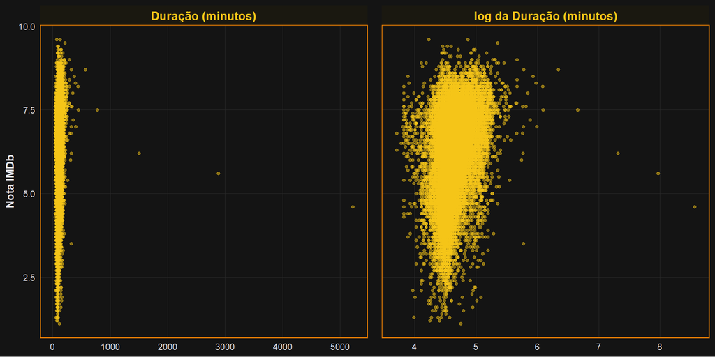

## 4.4 vote X rating_imdb

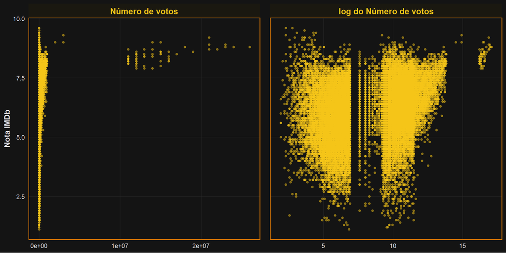

## 4.5 nomination X rating_imdb

[figure not shown]

## 4.6 rating_mpa X rating_imdb

[figure not shown]

## 4.7 genre X rating_imdb

[figure not shown]

## 4.8 language X rating_imdb

[figure not shown]

# 5 Resultados

## 5.1 O modelo

```r
summary(modelo)
```

```
Call:
lm(formula = rating_imdb ~ year + log1p(duration_min) + log1p(vote) +
    log1p(nomination) + rating_mpa + genre + language, data = df_modelo,
    weights = pesos_nomination)

Weighted Residuals:
    Min      1Q  Median      3Q     Max
-9.2808 -0.6164  0.0881  0.7048  5.2603

Coefficients:
                              Estimate Std. Error t value Pr(>|t|)
(Intercept)                 16.3969225  0.6510409  25.186  < 2e-16 ***
year                        -0.0075882  0.0003166 -23.968  < 2e-16 ***
log1p(duration_min)          0.6648642  0.0274909  24.185  < 2e-16 ***
log1p(vote)                  0.1293616  0.0027010  47.894  < 2e-16 ***
log1p(nomination)            0.2595312  0.0044210  58.705  < 2e-16 ***
rating_mpaAdulto/Restrito   -0.0231242  0.0148009  -1.562    0.118
rating_mpaLivre              0.2849136  0.0265382  10.736  < 2e-16 ***
rating_mpaModerado           0.1009161  0.0188213   5.362 8.29e-08 ***
rating_mpaOutros             0.3173478  0.0199598  15.899  < 2e-16 ***
rating_mpaSem Classificação  0.1507154  0.0183654   8.207 2.36e-16 ***
genreComédia/Musical         0.2169183  0.0146512  14.806  < 2e-16 ***
genreDocumentário/Crime      0.8926918  0.0189421  47.127  < 2e-16 ***
genreDrama                   0.4749826  0.0141453  33.579  < 2e-16 ***
genreFicção/Fantasia         0.2494093  0.0249359  10.002  < 2e-16 ***
genreOutros                  0.7881906  0.1869496   4.216 2.49e-05 ***
genreTerror/Suspense        -0.1747896  0.0200234  -8.729  < 2e-16 ***
languageLínguas Asiáticas    0.2593797  0.0181292  14.307  < 2e-16 ***
languageLínguas Europeias    0.3045506  0.0218508  13.938  < 2e-16 ***
languageLínguas Latinas      0.1651758  0.0150728  10.959  < 2e-16 ***
languageOutros               0.6631813  0.0238120  27.851  < 2e-16 ***
---
Signif. codes:  0 '***' 0.001 '**' 0.01 '*' 0.05 '.' 0.1 ' ' 1

Residual standard error: 1.101 on 32830 degrees of freedom
Multiple R-squared:  0.3949,    Adjusted R-squared:  0.3946
F-statistic:  1128 on 19 and 32830 DF,  p-value: < 2.2e-16
```

- n = 32.850
- weights = `nomination`
- $R^{2}_{ajustado}$ = 0,3946
- $p\text{-valor}_F$ < 2,2e-16
- $\sqrt{QM_{res}}$ = 1,101
- $QM_{res}$ = 1,21

## 5.2 ANOVA

```r
anova(modelo)
```

```
Analysis of Variance Table

Response: rating_imdb
                       Df Sum Sq Mean Sq F value    Pr(>F)
year                    1   1430  1429.9 1178.96 < 2.2e-16 ***
log1p(duration_min)     1   6716  6715.7 5537.18 < 2.2e-16 ***
log1p(vote)             1   4218  4217.8 3477.65 < 2.2e-16 ***
log1p(nomination)       1   6194  6193.9 5106.97 < 2.2e-16 ***
rating_mpa              5   2074   414.9  342.08 < 2.2e-16 ***
genre                   6   4253   708.9  584.46 < 2.2e-16 ***
language                4   1102   275.6  227.21 < 2.2e-16 ***
Residuals           32830  39817     1.2
---
Signif. codes:  0 '***' 0.001 '**' 0.01 '*' 0.05 '.' 0.1 ' ' 1
```

- $SQ_{reg}$ = 25.987
- $SQ_{res}$ = 39.817
- $SQ_{tot}$ = 65.804
- $R^{2}$ = 0,3949

## 5.3 FIV`s & PRESS

```r
car::vif(modelo)
```

```
                        GVIF Df GVIF^(1/(2*Df))
year                1.558420  1        1.248367
log1p(duration_min) 1.356850  1        1.164839
log1p(vote)         2.022012  1        1.421975
log1p(nomination)   1.948567  1        1.395911
rating_mpa          2.270492  5        1.085455
genre               1.309478  6        1.022723
language            1.749327  4        1.072405
```

- Maior FIV = 1,421975² = 2,02 < 3

```r
e_pond <- residuals(modelo) * sqrt(pesos_nomination)
h <- lm.influence(modelo)$hat
press_resid_pond <- e_pond / (1 - h)
PRESS_pond <- sum(press_resid_pond^2)
PRESS_pond
```

```
[1] 39876.13
```

- $PRESS$ = 39.876,13
- $R^{2}_{predito}$ = 0,3940
- $R^2$ = 0,3949

## 5.4 Resíduos Studentizados

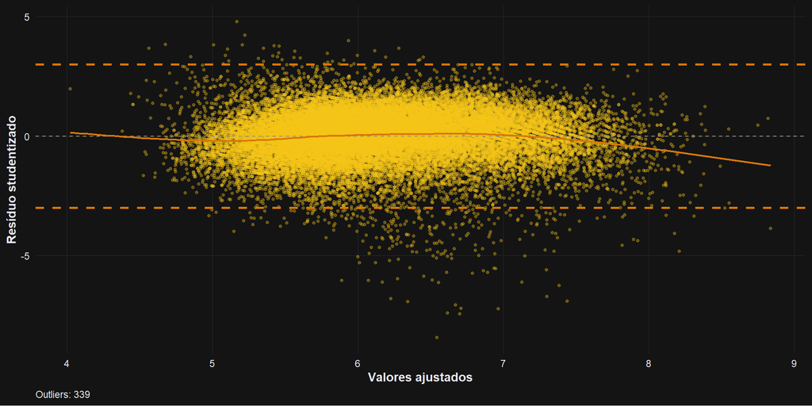

## 5.5 QQ-plot

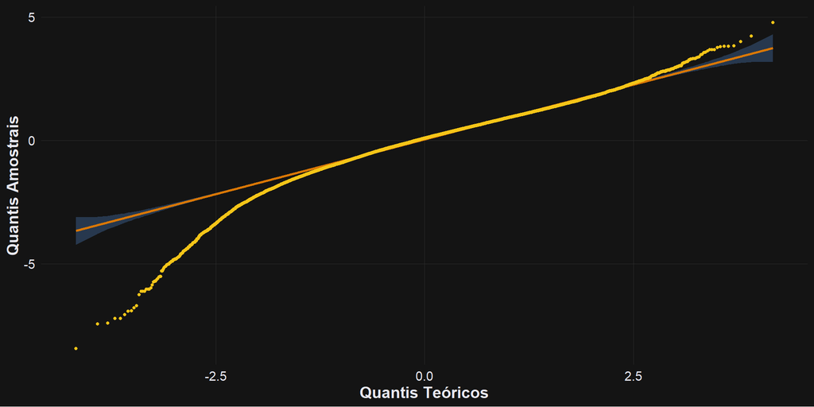

## 5.6 Alavanca & Influência

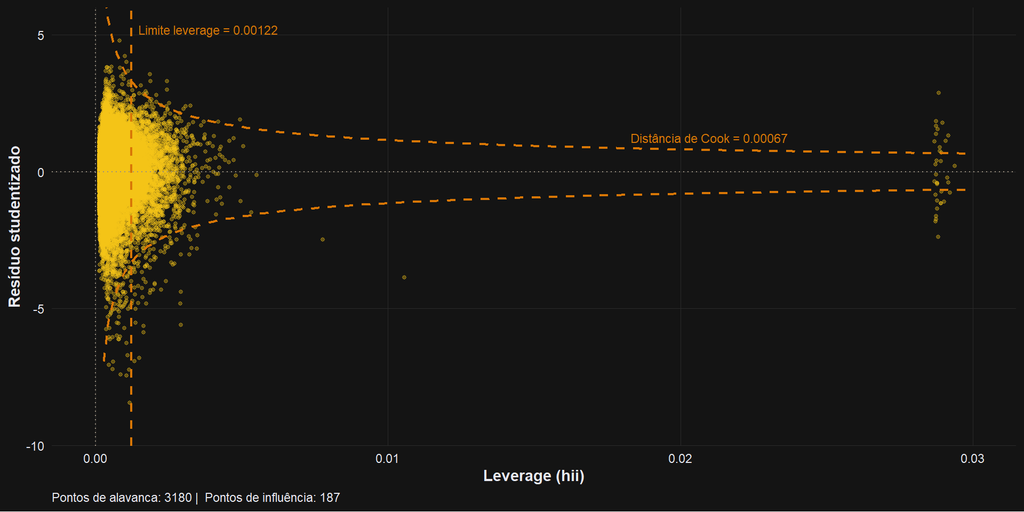

# 6 Conclusão

## 6.1 Conclusão

**O Modelo**

- Explica 39,46% da variabilidade;
- Heterocedástico;
- Resíduos não-normais;
- Multicolinearidade ausente.

**Melhorias**

- Adição de outras variáveis, após uma redução de categorias;
- Possível modelo logístico, com a nota sendo discretizada.

# 7 Referências

- CINI, Karl; ABELA, John. Forecasting film audience ratings: A natural language processing approach to script and production data. Entertainment Computing, v. 55, 101043, 2025
- HSU, Ping-Yu; SHEN, Yuan-Hong; XIE, Xiang-An. Predicting Movies User Ratings with Imdb Attributes. In: Rough Sets and Knowledge Technology (RSKT). Springer International Publishing, p. 444-453, 2014
- RUDRO, Md. Faishal Ahmed et al. Meta-Ensemble Learning for IMDb Ratings: A Stacked Hybrid Model Integrating Gradient Boosting and Deep Neural Networks. Research Square (Preprint), 2025. DOI: 10.21203/rs.3.rs-6153928/v1
- Projetos e Repositórios Técnicos (GitHub/RPubs) BURNS, Nathan. Linear-Regression-for-IMDB-Movie-Ratings. GitHub Repository, 2018. Disponível em: https://github.com/nateofspades/Linear-Regression-for-IMDB-Movie-Ratings
- CHANDRA, Venkatesh. IMDb-Movie-Ratings-Predictions-using-R. GitHub Repository, 2019. Disponível em: https://github.com/chandravenky/IMDb-Movie-Ratings-Predictions-using-R
- MIYASHIRO, Caio H. K. Regression Modelling Project: Predictions for the IMDB Ratings. RPubs, [s.d.]. Disponível em: https://rpubs.com/caiomiyashiro/126938
- ALMEIDA, Núbia Karla de Oliveira. Caderno de Anotações de Modelos Lineares 1: Graduação em Estatística. Niterói: Universidade Federal Fluminense (UFF), 2025.